# Gail Instructor Support Group Data

### **September 25, 2019 to October 09, 2019**

### Session 11

#### **At the end of today’s session, I CAN: Explain when to best utilize different types of capital, such as lines of credit, debt equity, and working capital.**

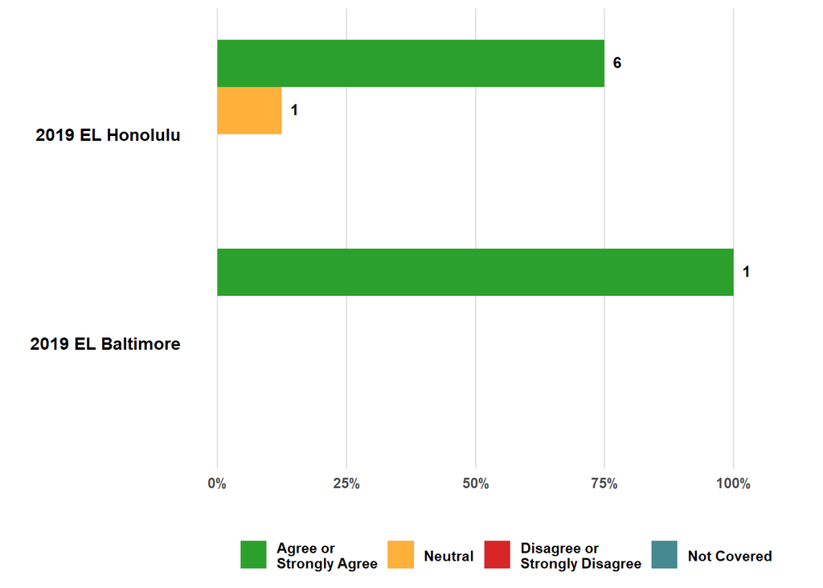

#### **At the end of today’s session, I CAN: Determine what type of funding is appropriate for my business now.**

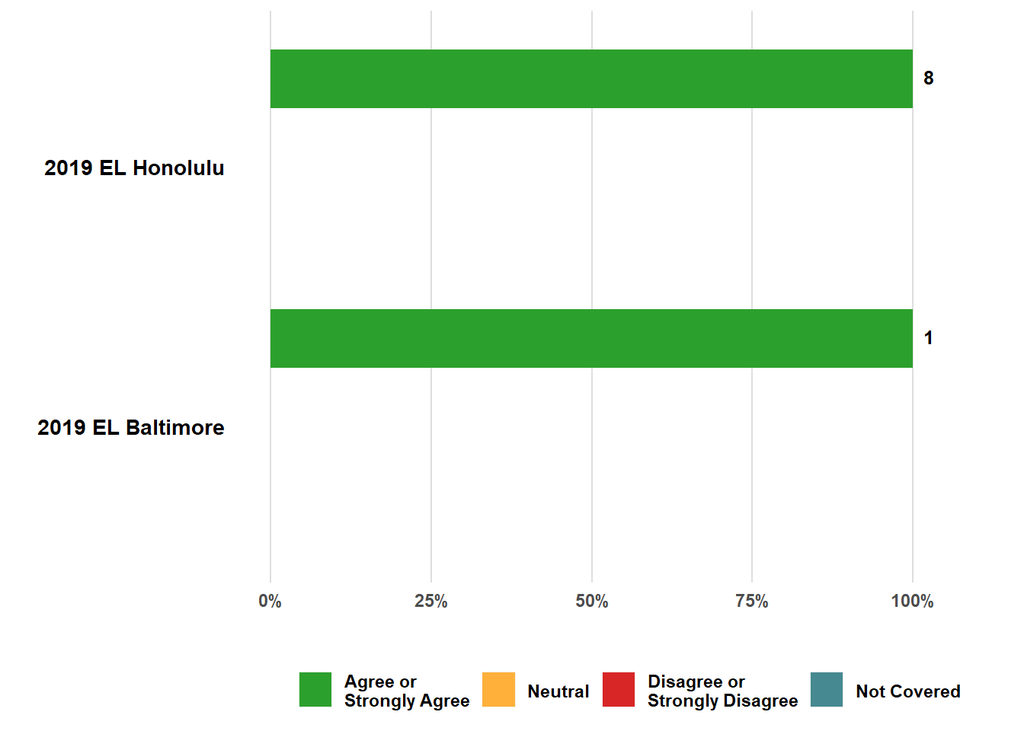

#### **At the end of today’s session, I CAN: Describe the continuum of public funding available from city, state, and federal governments and from private sources (e.g., micro-financing, commercial loans, angel/venture capital).**

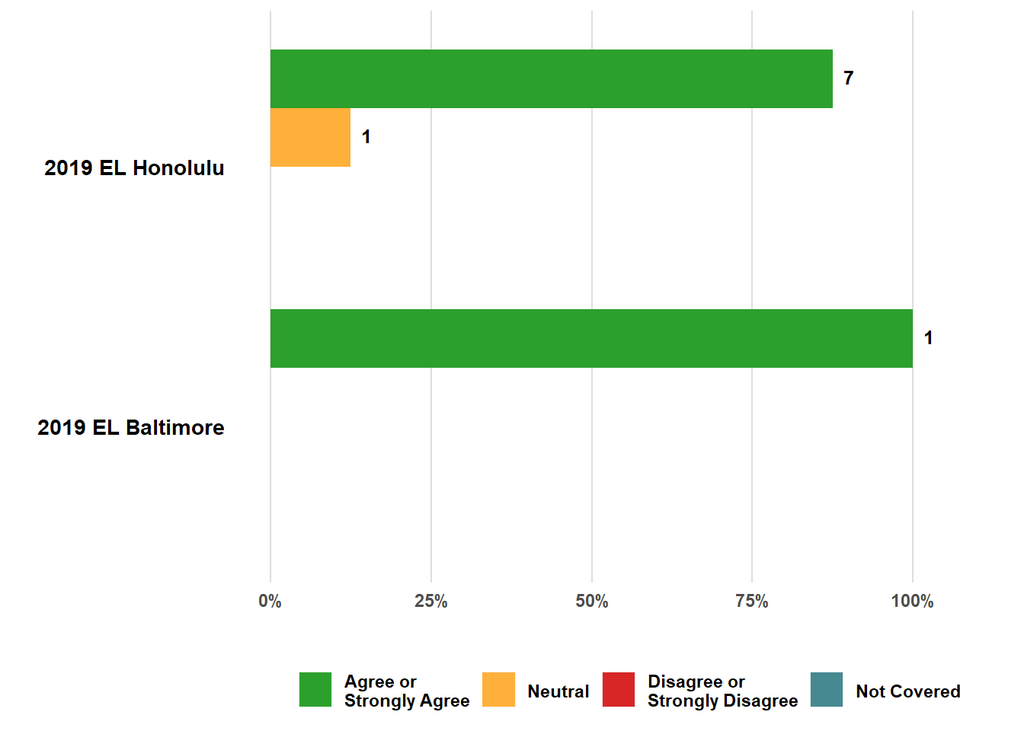